# Proyecto final - Lenguajes Mineria de datos

### Colegio Universitario de Cartago

### Profesor: Osvaldo Gonzalez Chaves

### Primer Cuatrimestre, 2025

# Contenido

## Introducción

Este proyecto se centra en la aplicación de las técnicas aprendidas en este curso para analizar el conjunto de datos “ARCHIVO_VIOLENCIA_DOMESTICA.tsv”. Utilizando bibliotecas de R, el objetivo principal es extraer información relevante y responder a las preguntas de investigación planteadas, además de generar estadísticas descriptivas que permitan comprender mejor los datos.

## Set de datos

El archivo seleccionado, “ARCHIVO_VIOLENCIA_DOMESTICA.tsv”, contiene registros de denuncias por violencia doméstica a nivel nacional desde 2015 hasta 2025, obtenidos del portal del Organismo de Investigación Judicial. A continuación, se explican las variables presentes en este conjunto de datos.

| Variable | Tipo | Descripcion |
| --- | --- | --- |
| Anno | int | Año de la estadistica |
| Mes | int | Mes de la estadistica |
| NombreMes | texto | Descripción del mes |
| NombreMateria | texto | Nombre de la materia |
| NombreCircuito | texto | Nombre del circuito |
| NombreDespacho | texto | Descripción del despacho |
| NombreTipoDespacho | texto | Descripción del tipo de despacho |
| CirculanteInicial | int | Cantidad de expedientes activos al iniciar el mes |
| CirculanteInicialLeg | int | Subconjunto del apartado anterior, en donde el tipos de caso es “Legajo”, válido para despachos laborales y contenciosos. |
| Entrados | int | Cantidad de expedientes entrados como nuevos durante el mes. |
| TestimoniosPiezas | int | Subconjunto de los entrados, en donde el expediente sea un testimonio de piezas. |
| Legajos | int | Subconjunto de los entrados, en donde el expediente sea un “legajo”. |
| Reentrados | int | Cantidad de expedientes reentrados durante el mes. |
| TErminadosXIncompetencia | int | Subconjunto de los terminados, en donde el motivo de término sea “Por Incompetencia” |
| AbandonadosOInactivos | int | Subconjunto de los terminados, en donde el motivo de término sea “Abandonado ó Inactivo” |
| Terminasdos | int | Cantidad de expedientes finalizados durante el mes. |
| CirculanteFinal | int | Cantidad de expedientes activos al finalizar el mes. |
| CirculanteFinalLegajos | int | Subconjunto del apartado anterior, en donde el tipos de caso es “Legajo”, válido para despachos laborales y contenciosos. |

## Estadísticas Básicas

Para aquellos valores numericos del dataset se encuentran las siguientes estadisticas

| variable | Media | Mediana | Moda |
| --- | --- | --- | --- |
| CirculanteInicial | 587.7595905 | 386 | 84 |
| CirculanteInicialLeg | 0.0000000 | 0 | 0 |
| Entrados | 61.6674479 | 40 | 9 |
| TestimoniosPiezas | 13.0511903 | 3 | 0 |
| Legajos | 0.0000000 | 0 | 0 |
| Reentrados | 0.5901073 | 0 | 0 |
| TerminadosXImcompetencia | 8.2380659 | 1 | 0 |
| AbandonadosOInactivos | 0.0000000 | 0 | 0 |
| Terminasdos | 67.5211546 | 38 | 0 |
| CirculanteFinal | 587.1793512 | 386 | 43 |
| CirculanteFinalLegajos | 0.0000000 | 0 | 0 |

## Correlaciones

Primero, analicemos la presencia de valores NA en nuestras variables numéricas:

Análisis de Valores Faltantes (NA)

|  | Variable | Cantidad.de.NAs | Porcentaje.de.NAs |
| --- | --- | --- | --- |
| CirculanteInicial | CirculanteInicial | 0 | 0 |
| CirculanteInicialLeg | CirculanteInicialLeg | 0 | 0 |
| Entrados | Entrados | 0 | 0 |
| TestimoniosPiezas | TestimoniosPiezas | 0 | 0 |
| Legajos | Legajos | 0 | 0 |
| Reentrados | Reentrados | 0 | 0 |
| TerminadosXImcompetencia | TerminadosXImcompetencia | 0 | 0 |
| AbandonadosOInactivos | AbandonadosOInactivos | 0 | 0 |
| Terminasdos | Terminasdos | 0 | 0 |
| CirculanteFinal | CirculanteFinal | 0 | 0 |
| CirculanteFinalLegajos | CirculanteFinalLegajos | 0 | 0 |

Para analizar las relaciones entre las variables numéricas del conjunto de datos, se presenta la siguiente matriz de correlaciones:

Matriz de Correlación

|  | CirculanteInicial | CirculanteInicialLeg | Entrados | TestimoniosPiezas | Legajos | Reentrados | TerminadosXImcompetencia | AbandonadosOInactivos | Terminasdos | CirculanteFinal | CirculanteFinalLegajos |
| --- | --- | --- | --- | --- | --- | --- | --- | --- | --- | --- | --- |
| CirculanteInicial | 1.00 | NA | 0.80 | 0.48 | NA | 0.18 | -0.08 | NA | 0.80 | 1.00 | NA |
| CirculanteInicialLeg | NA | 1 | NA | NA | NA | NA | NA | NA | NA | NA | NA |
| Entrados | 0.80 | NA | 1.00 | 0.72 | NA | 0.15 | 0.44 | NA | 0.72 | 0.80 | NA |
| TestimoniosPiezas | 0.48 | NA | 0.72 | 1.00 | NA | 0.11 | 0.56 | NA | 0.53 | 0.48 | NA |
| Legajos | NA | NA | NA | NA | 1 | NA | NA | NA | NA | NA | NA |
| Reentrados | 0.18 | NA | 0.15 | 0.11 | NA | 1.00 | 0.01 | NA | 0.19 | 0.17 | NA |
| TerminadosXImcompetencia | -0.08 | NA | 0.44 | 0.56 | NA | 0.01 | 1.00 | NA | -0.03 | -0.08 | NA |
| AbandonadosOInactivos | NA | NA | NA | NA | NA | NA | NA | 1 | NA | NA | NA |
| Terminasdos | 0.80 | NA | 0.72 | 0.53 | NA | 0.19 | -0.03 | NA | 1.00 | 0.76 | NA |
| CirculanteFinal | 1.00 | NA | 0.80 | 0.48 | NA | 0.17 | -0.08 | NA | 0.76 | 1.00 | NA |
| CirculanteFinalLegajos | NA | NA | NA | NA | NA | NA | NA | NA | NA | NA | 1 |

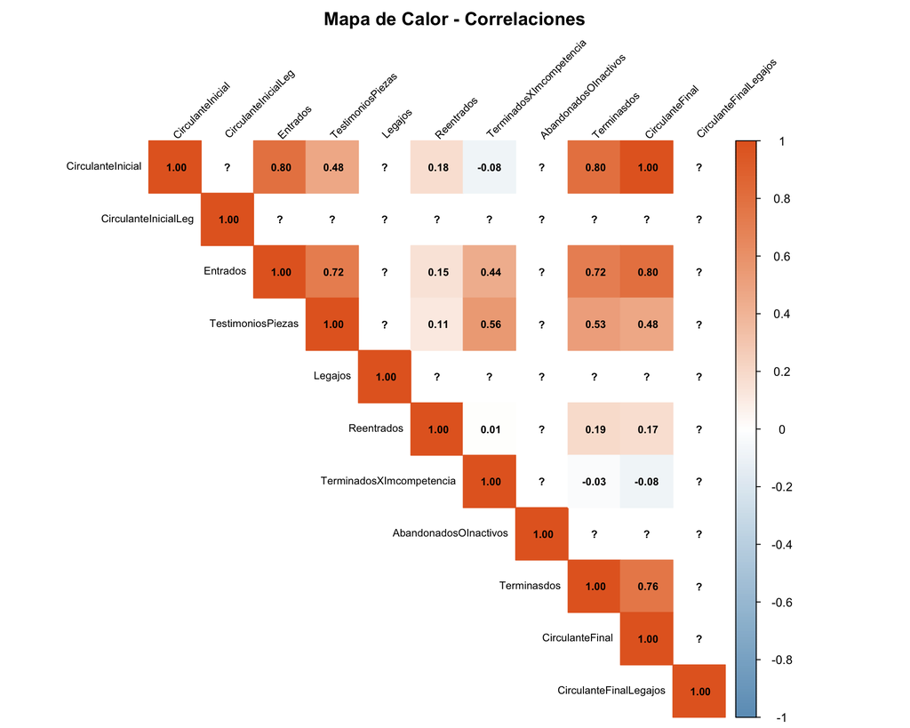

## Valores Atipicos

Para visualizar la distribución y detectar valores atípicos en las variables numéricas, se presentan los siguientes diagramas de caja:

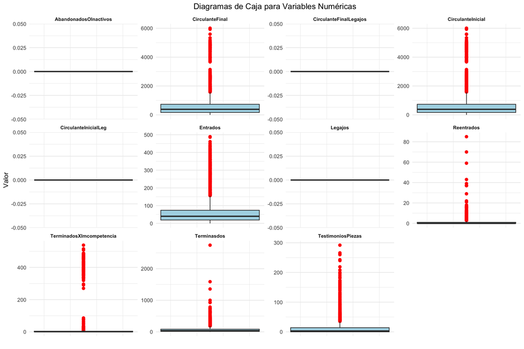

Los diagramas de caja nos permiten observar: - La distribución de los datos para cada variable - La presencia de valores atípicos (puntos rojos) - La mediana y los cuartiles de cada variable